# Poisson GLM

## Introduction

Understanding patterns of electricity consumption is important for improving energy efficiency and managing demand. In this analysis, we focus on the frequency of **high-consumption days** at the household level, defined as days where electricity usage exceeds the household-specific median.

The response variable is a **count**, representing the number of such days within a given month. Since count data are non-negative integers and typically exhibit a relationship between the mean and variance, a **Poisson Generalised Linear Model (GLM)** is an appropriate modelling framework.

The objective of this section is to investigate how weather conditions, building characteristics, and household composition influence the rate of high-consumption days. In particular, we aim to identify the key drivers of consumption frequency and quantify their effects using interpretable model coefficients.

The analysis proceeds by fitting a Poisson GLM with a log-link function and an offset to account for differences in the number of observed days per month. The results are then interpreted in terms of **rate ratios**, followed by an assessment of model assumptions and potential limitations.

## Data and Model Setup

### Response Variable and Data Structure

The analysis is conducted on data aggregated at the **household–month level**, where each observation corresponds to a specific household in a given month.

The response variable, $Y_i = \text{n\_high\_days}_i$, represents the number of days within the month in which electricity consumption exceeds the household-specific median. As such, the response is a **count variable**, taking non-negative integer values.

This aggregation allows us to model the **frequency of high-consumption events** rather than individual daily observations, providing a more stable and interpretable outcome.

### Exposure and Offset

The number of observed days may vary slightly across household–months. To account for this, an **exposure variable** is included, defined as the number of observed days $n\_days_i$ in each month.

Rather than modelling the raw count directly, we incorporate the logarithm of the exposure as an **offset term**, $\log(n\_days_i)$, in the model. This ensures that the model estimates the **rate of high-consumption days per observed day**, making observations comparable across different months.

Including an offset is standard practice in Poisson models when exposure differs across observations, and it allows the interpretation of coefficients in terms of multiplicative effects on the rate.

## Model Specification

### Poisson Model

Let $Y_i$ denote the number of high-consumption days for household–month $i$.  
We assume that the response follows a Poisson distribution:

$$Y_i \sim \text{Poisson}(\lambda_i)$$

where $\lambda_i = \mathbb{E}[Y_i]$ is the expected number of high-consumption days.

The Poisson model is appropriate for count data, as it ensures non-negative predictions and allows the variance to depend on the mean.

A log-link function is used to relate the expected value $\lambda_i$ to the linear predictor. This guarantees that the expected count remains positive and enables a multiplicative interpretation of the coefficients.

### Model Equation

The relationship between the predictors and the expected count is given by:

$$\begin{aligned}
\log(\lambda_i) &=
\beta_0 \\
&\quad + \beta_1 \, \text{heating\_degree\_days}_i \\
&\quad + \beta_2 \, \text{temp\_avg}_i \\
&\quad + \beta_3 \, \text{living\_area}_i \\
&\quad + \beta_4 \, \text{building\_type}_i \\
&\quad + \beta_5 \, \text{heatpump\_type}_i \\
&\quad + \beta_6 \, \text{has\_floor\_heating}_i \\
&\quad + \beta_7 \, \text{n\_residents}_i \\
&\quad + \beta_8 \, \text{share\_weekend}_i \\
&\quad + \log(n\_days_i)
\end{aligned}$$

where:

- $\beta_0$: intercept
- $\beta_1, \dots, \beta_8$: regression coefficients associated with the predictors
- $n\_days_i$: number of observed days (offset)
- $\lambda_i$: expected number of high-consumption days

The inclusion of $\log(n\_days_i)$ as an offset ensures that the model estimates a **rate** rather than a raw count.

## Results

### Model Output

The Poisson GLM was fitted using all available predictors describing weather conditions, building characteristics, and household composition. The estimated coefficients are summarised below:

```r
mod_pois <- readRDS("../models/poisson_glm/mod_pois.rds")
summary(mod_pois)
```

```
##
## Call:
## glm(formula = form, family = poisson(link = "log"), data = dat_count,
##     offset = log_n_days)
##
## Coefficients:
##                              Estimate Std. Error z value Pr(>|z|)
## (Intercept)                -1.751e+00  1.385e-01 -12.645   <2e-16 ***
## heating_degree_days        -1.363e-03  4.401e-03  -0.310   0.7567
## temp_avg                   -8.920e-02  4.825e-03 -18.487   <2e-16 ***
## living_area                 8.831e-04  5.513e-05  16.017   <2e-16 ***
## building_typehouse          1.533e+00  8.413e-02  18.222   <2e-16 ***
## heatpump_typeground-source -9.726e-02  9.340e-03 -10.413   <2e-16 ***
## has_floor_heating1          1.226e-01  1.218e-02  10.072   <2e-16 ***
## n_residents                 8.493e-02  3.935e-03  21.582   <2e-16 ***
## share_weekend              -4.085e-01  1.860e-01  -2.196   0.0281 *
## ---
## Signif. codes:  0 '***' 0.001 '**' 0.01 '*' 0.05 '.' 0.1 ' ' 1
##
## (Dispersion parameter for poisson family taken to be 1)
##
##     Null deviance: 43758  on 3299  degrees of freedom
## Residual deviance: 27530  on 3291  degrees of freedom
## AIC: 39292
##
## Number of Fisher Scoring iterations: 6
```

Most predictors show statistically significant effects on the rate of high-consumption days, with the exception of heating degree days.

### Coefficient Interpretation (Rate Ratios)

To interpret the model, coefficients are exponentiated to obtain **rate ratios**, which describe multiplicative changes in the expected rate of high-consumption days, holding all other variables constant.

This indicates that households living in **houses** have a rate of high-consumption days that is about **4.6 times higher** than households living in **flats**, all else being equal.

Thus, each additional resident increases the expected rate by approximately **9%**.

This implies that a one-unit increase in average temperature is associated with a **9% decrease** in the expected rate of high-consumption days.

## Visualisation

### Key Relationships

To complement the model results, we visualise key relationships between selected predictors and the number of high-consumption days.

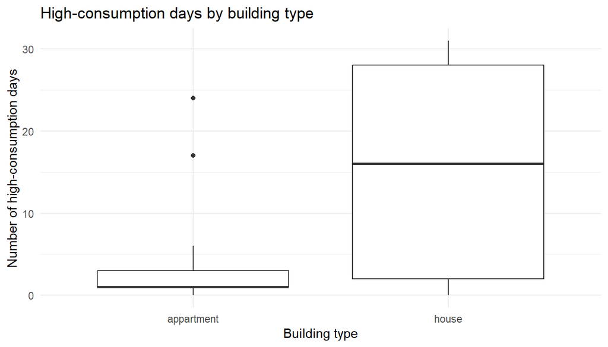

The boxplot highlights substantial differences between building types, with houses showing higher and more variable consumption levels compared to flats.

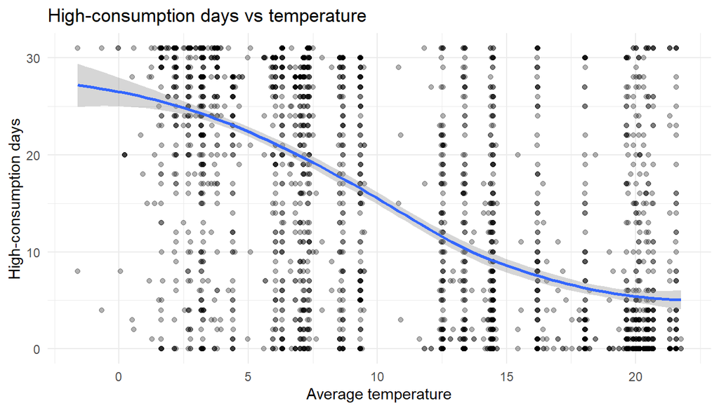

The relationship with temperature suggests a decreasing trend, consistent with reduced heating demand at higher temperatures.

### Rate Ratio Plot

To summarise the model results, we visualise exponentiated coefficients (rate ratios) along with their 95% confidence intervals.

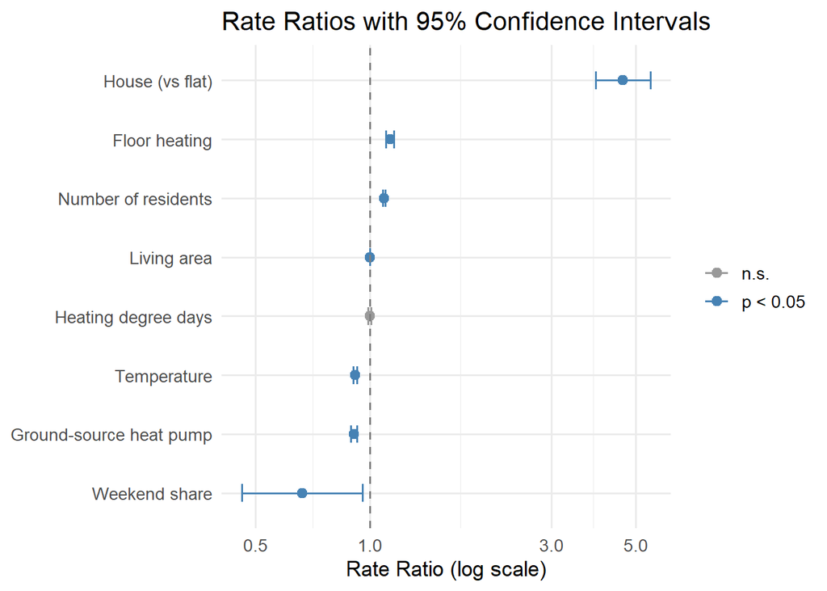

## Model Diagnostics

### Model Assumptions

The Poisson GLM relies on several key assumptions. First, the response variable must follow a Poisson distribution, implying that the mean and variance of the data are equal. Second, observations are assumed to be independent. Finally, the log-link function ensures a correct relationship between the expected count and the predictors.

In practice, the most critical assumption to verify is the equality of mean and variance, as violations of this assumption can affect statistical inference.

### Overdispersion

To assess overdispersion, we compare the residual deviance to the degrees of freedom. In this model, the ratio is approximately 8.36, which is substantially larger than 1.

This provides strong evidence of **overdispersion**, indicating that the variability in the data exceeds what is assumed under the Poisson distribution. As a consequence, standard errors are underestimated and p-values may be overly optimistic.

### Quasi-Poisson Comparison

To account for overdispersion, a quasi-Poisson model was fitted using the same specification.

While the estimated coefficients remain unchanged, the standard errors increase, leading to more conservative inference. In particular, some variables that appeared statistically significant under the Poisson model—such as the share of weekend days—lose their significance after this adjustment.

Overall, although the direction and magnitude of the effects are stable, the quasi-Poisson model provides a more reliable basis for statistical inference.

## Conclusion

Overall, the model provides useful insights into the determinants of high-consumption behaviour, but also highlights the importance of carefully validating model assumptions. Future work could consider alternative approaches, such as the negative binomial model, to better account for overdispersion and improve inference.